# DAND Final project: Bike sharing

# Explanatory Presentation

#### part of Udacity Data Analyst formation, May 2020, v2

# Overview

Bay Area Bike Share (now Ford GoBike) provides on-demand bike rentals for customers in San Francisco, Redwood City, Palo Alto, Mountain View, and San Jose.

Users can unlock bikes from various stations throughout each city, and return them to any station within the same city. Clients pay for the service either through a yearly subscription or by purchasing a 24-hour or 3-day pass. Under service conditions, they can make an unlimited number of trips: trips under thirty minutes in length have no additional charge, longer trips will incur overtime fees.

Users that pay the subscription are identified as "Subscribers" in this analysis. Users that purchase the passes, are called "Customers".

The data and details of the service can be founde here: https://www.lyft.com/bikes/bay-wheels/system-data

# Introduction

**In this analysis we will explore all the rides from 2019.**

How many rides?

Who used the bikes most during the week? Subscribers or Customers? What about the weekends?

What are the peak times during the week? And weekend?

Does the volume of rides are similar during the year? Who rides most?

### Hope you enjoy reading it as I have enjoyed preparing.

```python
#Import needed packages

import pandas as pd
import numpy as np
import matplotlib.pyplot as plt
%matplotlib inline
import requests
import tweepy
import time
import json
import seaborn as sns
import math
from datetime import datetime
from functools import reduce

from functions_for_this_analysis import haversine
```

It is important to pose these initial set of questions about some aspects of the service to guide the analysis, and then start understaing the data better in order to extract some insights:

**1) Service:**

-how many locations?

-what is the number of trips associated to locations? -what are the typical durations of the trips? -what are the typical distances?

**2) Customer habits:**

-What is the volume of trips over the year, month, week?

-During the week, what are the busiest times?

-What about the weekends?

-What is the split between subscribers and casual users?

-How many trips users take over the periods?

-What are the users profiles?

```python
#reading the file, so Analyst does not have to run all the processes above to query.
df_2019 = pd.read_csv('./data/2019_lyft_bike_sharing_rides.csv')
df_2019.head(1)
```

|  | start_time | end_time | start_station_id | start_station_name | start_station_latitude | start_station_longitude | end_station_id | end_station_name | end_station_latitude | end_station_longitude | bike_id | user_type | distance_km | duration_min | hour_of_the_day | day_of_the_week | month | day |
| --- | --- | --- | --- | --- | --- | --- | --- | --- | --- | --- | --- | --- | --- | --- | --- | --- | --- | --- |
| 0 | 2019-01-31 22:35:50 | 2019-02-01 00:28:04 | 245.0 | Downtown Berkeley BART | 37.870139 | -122.268422 | 266.0 | Parker St at Fulton St | 37.862464 | -122.264791 | 3532 | Subscriber | 0.9 | 112.22 | 22 | Thu | Jan | 31 |

```python
#convert date to datetime
df_2019['start_time']= pd.to_datetime(df_2019['start_time'])
df_2019['end_time']= pd.to_datetime(df_2019['end_time'])
```

```python
df_2019.shape
```

```
(2337862, 18)
```

```python
rides_per_day = df_2019.shape[0]/365
rides_per_day
```

```
6405.101369863014
```

```python
df_2019.groupby('user_type').user_type.count()
```

```
user_type
Customer       439872
Subscriber    1897990
Name: user_type, dtype: int64
```

```python
round(df_2019.groupby('user_type').user_type.count()[0] / df_2019.shape[0], 2)
```

```
0.19
```

```python
round(df_2019.groupby('user_type').user_type.count()[1] / df_2019.shape[0], 2)
```

```
0.81
```

# There were 2.33M rides in 2019, about 6.4K rides per day!

An average of 7138 rides on Mondays, 7720 on Tuesdays, 7549 on Wednesdays, 7741 on Thursdays, 7167 on Fridays, 4021 on Saturdays and 3620 on Sundays.

### The split per user type is shown below:

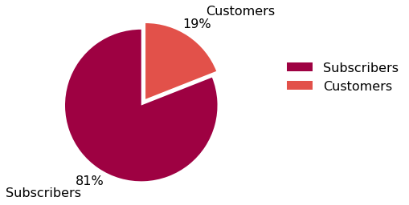

```python
#PIE chart - % of rides per day of week.


fig, ax = plt.subplots()
#plt.rcParams['font.sans-serif'] = 'Arial'
#plt.rcParams['font.family'] = 'sans-serif'
#plt.rcParams['text.color'] = '#909090'
plt.rcParams['axes.labelcolor']= '#909090'
plt.rcParams['xtick.color'] = '#909090'
plt.rcParams['ytick.color'] = '#909090'
plt.rcParams['font.size']=16
labels = ['Subscribers', 'Customers']
#color_palette_list = ['#009ACD', '#ADD8E6', '#63D1F4', '#0EBFE9','#C1F0F6', '#0099CC', '#66b3ff']

cmap = plt.get_cmap('Spectral')
colors = [cmap(i) for i in np.linspace(0, 1, 8)]


percentages = [round(df_2019.groupby('user_type').user_type.count()[1] / df_2019.shape[0], 2),
               round(df_2019.groupby('user_type').user_type.count()[0] / df_2019.shape[0], 2)]
explode=(0,0.1)

#ax.pie(percentages, explode=explode, labels=labels, colors=color_palette_list[0:7],
ax.pie(percentages, explode=explode, labels=labels, colors=colors,
       autopct='%1.0f%%',
       shadow=False, startangle=90,
       pctdistance=1.2,labeldistance=1.4)
ax.axis('equal')
#ax.set_title("Trips during the week and weekends")
ax.legend(frameon=False, bbox_to_anchor=(1.5,0.8))

fig = plt.gcf()
fig.savefig('pie_split_rides_week_and_weekends.png',bbox_inches='tight');
```

# How about the split between users over the months?

### Note that in December the number of Customers increase and reaches its highest point in the year.

#### Are they on vacation? Does that confirm that Subscribers are workers living in town? Let's dig in further now.

(Hit DOWN key)

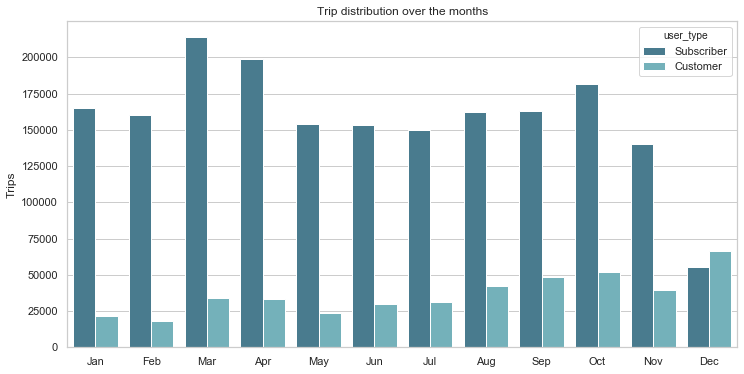

```python
plt.figure(figsize = [12,6])
sns.set(style="whitegrid")



sns.countplot(x="month", hue='user_type', palette = "GnBu_d",
              order=['Jan','Feb','Mar','Apr','May','Jun','Jul','Aug','Sep','Oct','Nov', 'Dec'], data = df_2019);


plt.title('Trip distribution over the months')
plt.ylabel('Trips');
plt.xlabel('');


fig = plt.gcf()
fig.savefig('histogram_usertype_week_spread.png',bbox_inches='tight');
```

```python
df_2019.query('user_type == "Subscriber"').duration_min.describe()
```

```
count    1.897990e+06
mean     1.063212e+01
std      8.405992e+00
min      1.520000e+00
25%      5.650000e+00
50%      8.800000e+00
75%      1.333000e+01
max      2.392500e+02
Name: duration_min, dtype: float64
```

```python
df_2019.query('user_type == "Customer"').duration_min.describe()
```

```
count    439872.000000
mean         17.686554
std          19.471574
min           1.520000
25%           8.280000
50%          12.920000
75%          20.150000
max         239.980000
Name: duration_min, dtype: float64
```

# Duration of the rides

(Hit DOWN key)

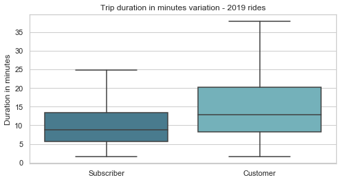

```python
plt.figure(figsize = [8,4])

sns.set(style="whitegrid")
sns.boxplot(data = df_2019, x = 'user_type', y = 'duration_min',
            showfliers=False, palette = 'GnBu_d').set(xlabel='',
            ylabel='Duration in minutes',
            title='Trip duration in minutes variation - 2019 rides')
fig = plt.gcf()
fig.savefig('box_plot_user_type_trip_duration.png',bbox_inches='tight');
```

```python
df_2019.query('user_type == "Subscriber"').distance_km.describe()
```

```
count    1.897990e+06
mean     1.699964e+00
std      1.039432e+00
min      1.000000e-01
25%      9.000000e-01
50%      1.400000e+00
75%      2.200000e+00
max      1.650000e+01
Name: distance_km, dtype: float64
```

```python
df_2019.query('user_type == "Customer"').distance_km.describe()
```

```
count    439872.000000
mean          1.920417
std           1.079074
min           0.100000
25%           1.100000
50%           1.700000
75%           2.500000
max          15.700000
Name: distance_km, dtype: float64
```

# Distance of the rides

(Hit DOWN key)

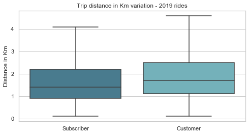

```python
plt.figure(figsize = [8,4])

sns.set(style="whitegrid")
box_plot = sns.boxplot(data = df_2019, x = 'user_type', y = 'distance_km',
            showfliers=False, palette = 'GnBu_d').set(xlabel='',
            ylabel='Distance in Km',
            title='Trip distance in Km variation - 2019 rides')



fig = plt.gcf()
fig.savefig('box_plot_user_type_trip_distance.png',bbox_inches='tight');
```

```python
df_2019.head(1)
```

|  | start_time | end_time | start_station_id | start_station_name | start_station_latitude | start_station_longitude | end_station_id | end_station_name | end_station_latitude | end_station_longitude | bike_id | user_type | distance_km | duration_min | hour_of_the_day | day_of_the_week | month | day |
| --- | --- | --- | --- | --- | --- | --- | --- | --- | --- | --- | --- | --- | --- | --- | --- | --- | --- | --- |
| 0 | 2019-01-31 22:35:50 | 2019-02-01 00:28:04 | 245.0 | Downtown Berkeley BART | 37.870139 | -122.268422 | 266.0 | Parker St at Fulton St | 37.862464 | -122.264791 | 3532 | Subscriber | 0.9 | 112.22 | 22 | Thu | Jan | 31 |

### Service Analysis:

```python
df_subscriber_week =  df_2019.query('user_type == "Subscriber" & (day_of_the_week == "Mon" | day_of_the_week == "Tue" | day_of_the_week == "Wed" | day_of_the_week == "Thu" | day_of_the_week == "Fri" )')
df_customer_week =  df_2019.query('user_type == "Customer" & (day_of_the_week == "Mon" | day_of_the_week == "Tue" | day_of_the_week == "Wed" | day_of_the_week == "Thu" | day_of_the_week == "Fri" )')

df_subscriber_weekend =  df_2019.query('user_type == "Subscriber" & (day_of_the_week == "Sat" | day_of_the_week == "Sun" )')
df_customer_weekend =  df_2019.query('user_type == "Customer" & (day_of_the_week == "Sat" | day_of_the_week == "Sun" )')

df_subscriber_week.user_type.count(),  df_customer_week.user_type.count(), df_subscriber_weekend.user_type.count(), df_customer_weekend.user_type.count()
```

```
(1619529, 320941, 278461, 118931)
```

```python
#Ratio week: almost 5x more subs than customer
df_subscriber_week.user_type.count() /  df_customer_week.user_type.count()
```

```
5.046189174957391
```

```python
#Ratio weekend. on the weekend that falls to about 2x only..
df_subscriber_weekend.user_type.count() /  df_customer_weekend.user_type.count()
```

```
2.341366002135692
```

```python
total_p_subscriber_week = (round(df_subscriber_week.user_type.count() / df_2019.query('day_of_the_week == "Mon" | day_of_the_week == "Tue" | day_of_the_week == "Wed" | day_of_the_week == "Thu" | day_of_the_week == "Fri"').user_type.count(), 2))*100
total_p_customer_week = (round(df_customer_week.user_type.count() / df_2019.query('day_of_the_week == "Mon" | day_of_the_week == "Tue" | day_of_the_week == "Wed" | day_of_the_week == "Thu" | day_of_the_week == "Fri" ').user_type.count(), 2))*100

total_p_subscriber_weekend = (round(df_subscriber_weekend.user_type.count() / df_2019.query('day_of_the_week == "Sat" | day_of_the_week == "Sun"').user_type.count(), 2))*100
total_p_customer_weekend = (round(df_customer_weekend.user_type.count() / df_2019.query('day_of_the_week == "Sat" | day_of_the_week == "Sun" ').user_type.count(), 2))*100

total_p_subscriber_week, total_p_customer_week, total_p_subscriber_weekend, total_p_customer_weekend
```

```
(83.0, 17.0, 70.0, 30.0)
```

```python
total_subscriber_rides_week = df_2019.query('day_of_the_week == "Mon" | day_of_the_week == "Tue" | day_of_the_week == "Wed" | day_of_the_week == "Thu" | day_of_the_week == "Fri"').user_type.count()
```

```python
total_subscriber_rides_weekend = df_2019.query('day_of_the_week == "Sat" | day_of_the_week == "Sun"').user_type.count()
```

```python
total_rides_mon = df_2019.query('day_of_the_week == "Mon"').user_type.count()
total_rides_tue = df_2019.query('day_of_the_week == "Tue"').user_type.count()
total_rides_wed = df_2019.query('day_of_the_week == "Wed"').user_type.count()
total_rides_thu = df_2019.query('day_of_the_week == "Thu"').user_type.count()
total_rides_fri = df_2019.query('day_of_the_week == "Fri"').user_type.count()
total_rides_sat = df_2019.query('day_of_the_week == "Sat"').user_type.count()
total_rides_sun = df_2019.query('day_of_the_week == "Sun"').user_type.count()
```

```python
total_rides_mon / 52, total_rides_tue /52 , total_rides_wed/52 ,total_rides_thu/52 ,total_rides_fri/52,total_rides_sat /52,total_rides_sun/52
```

```
(7138.115384615385,
 7720.75,
 7549.153846153846,
 7741.2692307692305,
 7167.442307692308,
 4021.980769230769,
 3620.173076923077)
```

```python
total_rides = df_2019.user_type.count()
```

# How is the ride distribution over the week?

(Hit DOWN key)

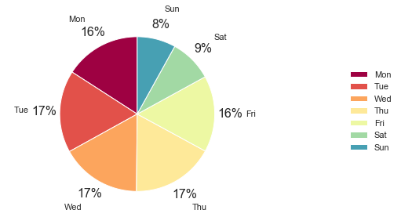

```python
#PIE chart - % of rides per day of week.


fig, ax = plt.subplots()
#plt.rcParams['font.sans-serif'] = 'Arial'
#plt.rcParams['font.family'] = 'sans-serif'
#plt.rcParams['text.color'] = '#909090'
plt.rcParams['axes.labelcolor']= '#909090'
plt.rcParams['xtick.color'] = '#909090'
plt.rcParams['ytick.color'] = '#909090'
plt.rcParams['font.size']=16
labels = ['Mon', 'Tue', 'Wed', 'Thu', 'Fri', 'Sat', 'Sun']
#color_palette_list = ['#009ACD', '#ADD8E6', '#63D1F4', '#0EBFE9','#C1F0F6', '#0099CC', '#66b3ff']

cmap = plt.get_cmap('Spectral')
colors = [cmap(i) for i in np.linspace(0, 1, 8)]


percentages = [df_2019.query('day_of_the_week == "Mon"').month.count()/total_rides,
               df_2019.query('day_of_the_week == "Tue"').month.count()/total_rides,
               df_2019.query('day_of_the_week == "Wed"').month.count()/total_rides,
               df_2019.query('day_of_the_week == "Thu"').month.count()/total_rides,
               df_2019.query('day_of_the_week == "Fri"').month.count()/total_rides,
               df_2019.query('day_of_the_week == "Sat"').month.count()/total_rides,
               df_2019.query('day_of_the_week == "Sun"').month.count()/total_rides]
explode=(0.,0.,0.,0.,0.,0.,0. )

#ax.pie(percentages, explode=explode, labels=labels, colors=color_palette_list[0:7],
ax.pie(percentages, explode=explode, labels=labels, colors=colors,
       autopct='%1.0f%%',
       shadow=False, startangle=90,
       pctdistance=1.2,labeldistance=1.4)
ax.axis('equal')
#ax.set_title("Trips during the week and weekends")
ax.legend(frameon=False, bbox_to_anchor=(1.5,0.8))

fig = plt.gcf()
fig.savefig('pie_split_rides_week_and_weekends.png',bbox_inches='tight');
```

# Monday to Friday - What are the busiest times over the day?

### People don't ride until late during the week.

### Peaks between 8-9am and 5-6pm, mainly fot the Subscribers. Are these folks riding to work?

### Notice that for the Customers, the volume of trips keeps steady between 10am-2pm. Would that be visitors?

(Hit DOWN key)

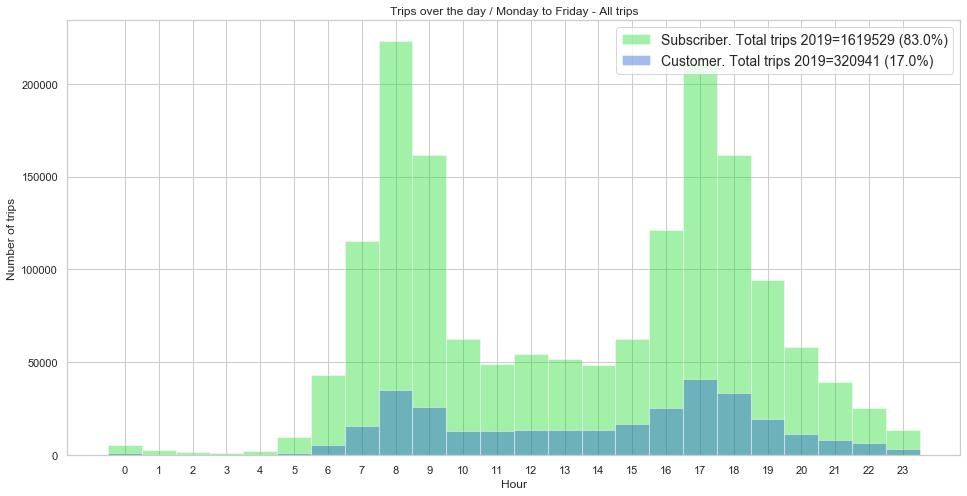

```python
#trips over the day from midnight to 23h - WEEK
plt.figure(figsize = [16,8])


bin_edges = np.arange(-0.5, 23.5+1, 1)
sns.set(style="whitegrid")

#palette = iter(sns.husl_palette(2))

label_subscriber = "Subscriber. Total trips 2019=" + str(df_subscriber_week.user_type.count()) + " (" + str(total_p_subscriber_week) + "%)"
label_customer = "Customer. Total trips 2019=" + str(df_customer_week.user_type.count()) + " (" + str(total_p_customer_week) + "%)"

sns.distplot(df_subscriber_week['hour_of_the_day'], kde = False, color='#19DB26',label=label_subscriber, bins = bin_edges)
sns.distplot(df_customer_week['hour_of_the_day'],kde = False, color='#1C56D6', label=label_customer, bins = bin_edges)



plt.xticks(np.arange(0, 24, 1));
plt.legend(prop={'size': 14})
plt.title('Trips over the day / Monday to Friday - All trips')
plt.xlabel('Hour')
plt.ylabel('Number of trips');

fig = plt.gcf()
fig.savefig('histogram_usertype_over_the_day_week.png',bbox_inches='tight');
```

# The weekends: what are the busiest times?

Behaviours are pretty much similar regardless of the user type: peak is late morning until late noon, but people still riding until late night..going home...after a few drinks..No driving, good job guys!

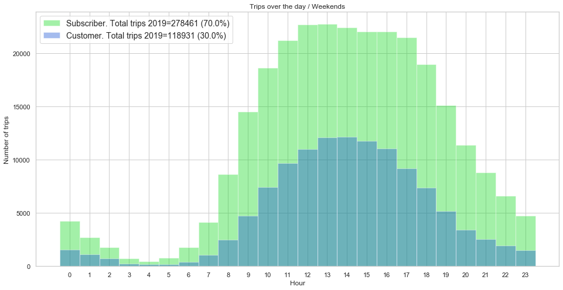

```python
#trips over the day from midnight to 23h - WEEKEND


plt.figure(figsize = [16,8])


bin_edges = np.arange(-0.5, 23.5+1, 1)
sns.set(style="whitegrid")

label_subscriber = "Subscriber. Total trips 2019=" + str(df_subscriber_weekend.user_type.count()) + " (" + str(total_p_subscriber_weekend) + "%)"
label_customer = "Customer. Total trips 2019=" + str(df_customer_weekend.user_type.count()) + " (" + str(total_p_customer_weekend) + "%)"



#sns.distplot(sns.color_palette("Paired"))
#sns.distplot(sns.color_palette("hls", 8))
#colors = ["windows blue", "amber", "greyish", "faded green", "dusty purple"]
#sns.distplot(sns.xkcd_palette(colors))

sns.distplot(df_subscriber_weekend['hour_of_the_day'], kde = False, color='#19DB26', label=label_subscriber, bins = bin_edges)
sns.distplot(df_customer_weekend['hour_of_the_day'],kde = False,color='#1C56D6', label=label_customer, bins = bin_edges)

plt.xticks(np.arange(0, 24, 1));
plt.legend(prop={'size': 14})
plt.title('Trips over the day / Weekends')
plt.xlabel('Hour')
plt.ylabel('Number of trips');
fig = plt.gcf()
fig.savefig('histogram_usertype_over_the_day_week.png',bbox_inches='tight');
```